# 01 · 从局部变化到向量几何与优化

## 目标 · Goal

用四个实验连接导数、线性变换、投影和梯度下降。每一步先写预测，再运行，再用等式核对图像。 需要的准备：坐标、向量点积、矩阵乘法；不要求预先掌握优化。

## 准备 · Setup

先在网页预测结果、拖动参数，再回到这里复算。代码只使用合成数据，不读取学习记录。 所有随机数使用 NumPy PCG64；固定种子可重现本 Notebook，**不意味着与网页的随机样本逐项一致**。 数学定义、参数和边界与网页一致。独立核验脚本另外直接读取网页原始样本，再用 NumPy/SciPy 复算。

运行环境：Python 3.12+，依赖见 `../requirements.txt`。从顶部顺序运行全部单元格；图表标签用英语，讲解用中文。

**Python · cell 3**

```
from pathlib import Path
import sys
candidates = [Path.cwd(), Path.cwd().parent, Path.cwd() / "python"]
source_dir = next((p for p in candidates if (p / "lab_reference.py").is_file()), None)
if source_dir is None:
    raise FileNotFoundError("从 python/notebooks 或 python 目录运行此 Notebook")
sys.path.insert(0, str(source_dir))
import numpy as np
from scipy.stats import norm, beta as beta_distribution
from numpy.polynomial.legendre import legvander
import matplotlib.pyplot as plt
import lab_reference as lab
%matplotlib inline
plt.rcParams.update({"figure.figsize": (9, 4.4), "figure.dpi": 125,
                     "font.size": 11, "axes.spines.top": False,
                     "axes.spines.right": False, "axes.grid": True,
                     "grid.alpha": .18, "axes.axisbelow": True})
BLUE, ORANGE, OLIVE, INK = "#24658c", "#bc6327", "#69743a", "#24323c"
SEED = 42
print("NumPy", np.__version__, "· seed", SEED, "· independent PCG64 draws")
```

```
NumPy 2.5.3 · seed 42 · independent PCG64 draws
```

## 实验 1 · 切线和有限差分

对 $f(x)=x^3-x$，在 $x=1$ 的精确导数为 $2$。前向差分误差为 $3xh+h^2$，中心差分误差为 $h^2$。 先预测：将 $h$ 减半，哪一种误差缩小更快？这里讨论截断误差；极小步长还会受到浮点消减影响。

**Python · cell 5**

```
x, h = 1., .5
result = lab.compute("tangent", x=x, h=h)
f = lambda t: t**3 - t
xx = np.linspace(-.2, 2.1, 240)
steps = np.logspace(-5, 0, 80)
forward = np.array([abs(lab.compute("tangent", x=x, h=t)["forward"]-2) for t in steps])
central = np.array([abs(lab.compute("tangent", x=x, h=t)["central"]-2) for t in steps])
fig, ax = plt.subplots(1, 2, figsize=(11,4.3), layout="constrained")
ax[0].plot(xx, f(xx), color=INK, label="f(x)")
ax[0].plot(xx, f(x)+2*(xx-x), "--", color=BLUE, label="Tangent")
ax[0].plot(xx, f(x)+result["forward"]*(xx-x), ":", color=ORANGE, label="Forward secant")
ax[0].scatter([x,x+h], [f(x),f(x+h)], color=ORANGE)
ax[0].set(xlabel="x", ylabel="f(x)", title="Local slope at x = 1"); ax[0].legend()
ax[1].loglog(steps,forward,color=ORANGE,label="Forward absolute error")
ax[1].loglog(steps,central,"--",color=BLUE,label="Central absolute error")
ax[1].set(xlabel="Step h",ylabel="Absolute derivative error",title="Truncation error"); ax[1].legend()
plt.show()
print({k: round(result[k],6) for k in ["exact","forward","central"]})
assert np.isclose(result["central"] - result["exact"], h*h)
```

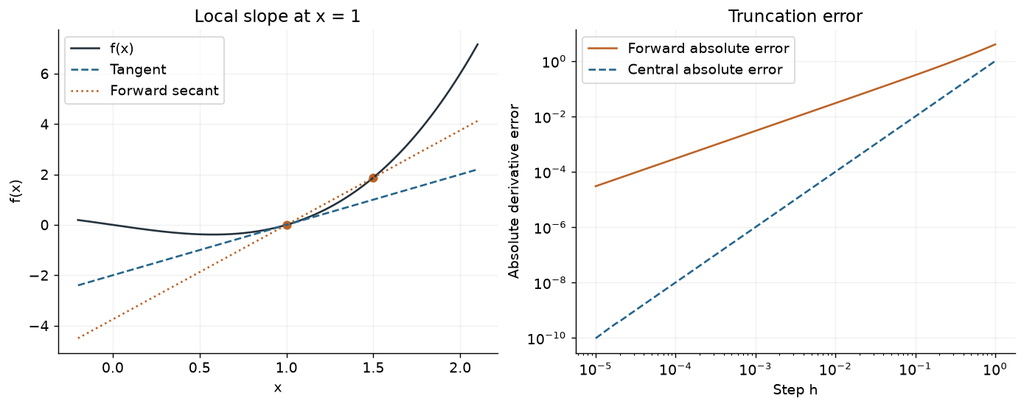

```
{'exact': 2.0, 'forward': 3.75, 'central': 2.25}
```

中心差分在此消去了关于 $h$ 的一次误差项。图中的 log-log 斜率对应误差阶数；这不保证对任意函数、任意步长都更准确。

**自己试：** 把 `x` 改成 0，再比较两种差分。为什么它们对这个奇函数恰好相同？

**核对思路**

在 x=0，前向误差中的 3xh 消失，两个误差均为 h²。

## 实验 2 · 矩阵改变方向与面积

采用列向量约定 $Av$。矩阵两列分别是两个标准基向量的像。行列式给出**带符号面积倍率**：负值表示方向翻转，零表示平面压缩到低维。

**Python · cell 8**

```
matrices = [("Shear",dict(a=1,b=.7,c=0,d=1)),
            ("Reflection",dict(a=-1,b=0,c=0,d=1)),
            ("Singular collapse",dict(a=1,b=1,c=1,d=1))]
square = np.array([[0,0],[1,0],[1,1],[0,1],[0,0]])
fig, axes = plt.subplots(1,3,figsize=(12,4),layout="constrained")
for ax,(name,params) in zip(axes,matrices):
    r=lab.compute("linear",**params); pts=r["vertices"]
    ax.plot(*square.T,"--",color=INK,label="Unit square")
    ax.plot(*pts.T,"o-",color=BLUE,label="Transformed")
    ax.set(xlim=(-1.5,2.5),ylim=(-.5,2.5),xlabel="x",ylabel="y",
           title=f"{name}: det = {r['determinant']:.1f}")
    ax.set_aspect("equal"); ax.legend(fontsize=9)
plt.show()
assert lab.compute("linear",a=1,b=1,c=1,d=1)["singular"]
```

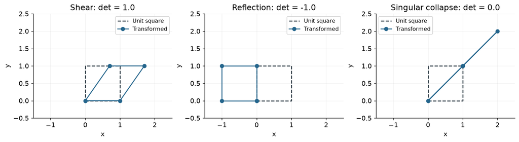

面积相同不代表变换相同：剪切仍可改变角度。奇异变换没有全平面的逆。

**自己试：** 找两个不同矩阵，行列式都为 1，但把同一单位向量送到不同位置。

## 实验 3 · 投影把误差分成正交部分

对单位向量 $u$，投影为 $(u^Tv)u$。残差 $r=v-(u^Tv)u$ 满足 $u^Tr=0$，因此平方长度满足勾股分解。 投影长度可以为负；这表示沿 $u$ 的反方向，不是长度范数为负。

**Python · cell 11**

```
r=lab.compute("projection",angle=30,vx=2,vy=1)
fig,ax=plt.subplots(layout="constrained")
for key,color,style in [("v",INK,"-"),("projection",BLUE,"--")]:
    value=r[key]; ax.plot([0,value[0]],[0,value[1]],style,color=color,label=key,linewidth=2.5)
ax.plot([r["projection"][0],r["v"][0]],[r["projection"][1],r["v"][1]],":",color=ORANGE,label="residual",linewidth=2.5)
ax.axhline(0,color="#aaa",linewidth=.7); ax.axvline(0,color="#aaa",linewidth=.7)
ax.set(xlabel="x",ylabel="y",title="Orthogonal projection",xlim=(-.2,2.5),ylim=(-.3,1.7))
ax.set_aspect("equal"); ax.legend(); plt.show()
print(f"u dot residual = {r['orthogonality']:.2e}")
print(f"||v||² = {r['norm2']:.8f}; ||projection||² + ||residual||² = {r['decomposedNorm2']:.8f}")
assert abs(r["orthogonality"])<1e-12
assert np.isclose(r["norm2"],r["decomposedNorm2"])
```

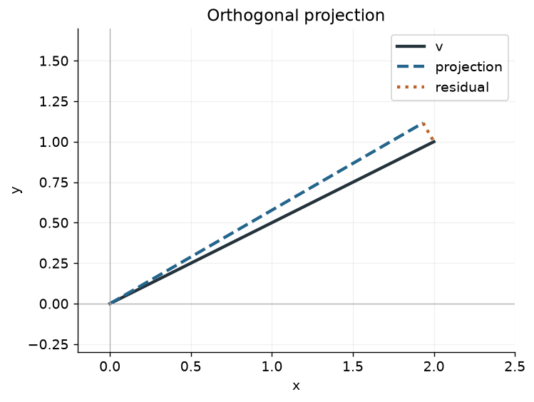

```
u dot residual = 6.94e-17
||v||² = 5.00000000; ||projection||² + ||residual||² = 5.00000000
```

**自己试：** 令向量与 $u$ 垂直，再令向量与 $u$ 平行；先预测投影和残差各为多少。

## 实验 4 · 梯度下降何时收敛

对 $f(x,y)=(x^2+Ly^2)/2$，每一步分别乘以 $1-\eta$ 和 $1-\eta L$。 对所有初始点收敛需要 $0<\eta<2/L$。等号处通常振荡；初始点恰好没有不稳定方向分量时可能例外。

**Python · cell 14**

```
L=4
fig,axes=plt.subplots(1,2,figsize=(11,4.3),layout="constrained")
for rate,color,style in [(.2,BLUE,"-"),(.5,OLIVE,"--"),(.6,ORANGE,":")]:
    r=lab.compute("gradient",rate=rate,condition=L,steps=25)
    if rate <= .5:
        axes[0].plot(r["x"],r["y"],style,color=color,marker=".",label=f"eta={rate}")
    axes[1].semilogy(r["step"],np.maximum(r["loss"],1e-15),style,color=color,label=f"eta={rate}")
axes[0].set(xlabel="x",ylabel="y",title="Stable and boundary trajectories")
axes[0].set_aspect("equal",adjustable="datalim")
axes[1].set(xlabel="Iteration",ylabel="Loss (log scale)",title="Stable, boundary, unstable")
for ax in axes: ax.legend()
plt.show()
stable=lab.compute("gradient",rate=.2)
assert np.all(np.diff(stable["loss"])<=1e-12)
boundary=lab.compute("gradient",rate=.5)
assert np.allclose(np.abs(boundary["y"]),2)
print("Stability bound:",2/L,"; boundary retains a nonzero y component")
```

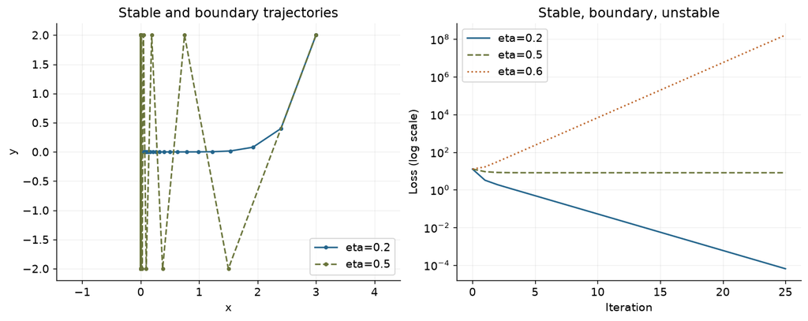

```
Stability bound: 0.5 ; boundary retains a nonzero y component
```

## 检查 · Checks

已运行的断言检验了中心差分、奇异变换、正交分解和步长边界。图像提供直觉，等式决定是否成立。

## 接下来 · Next steps

把梯度下降的 `condition` 从 4 改成 20；固定步长和按 $1/L$ 调整步长分别比较。回到网页拖动参数后，在这里写下稳定条件的推导。

来源：[MIT OCW 18.02SC 微积分](https://ocw.mit.edu/courses/18-02sc-multivariable-calculus-fall-2010/)、[MIT OCW 18.06 线性代数](https://ocw.mit.edu/courses/18-06-linear-algebra-spring-2010/)。精确二次递推在本 Notebook 直接代数推导；数值实现独立于网页。